# Exercise

```python
%matplotlib notebook
import pandas as pd
import numpy as np
import pydicom
import skimage
import matplotlib.pyplot as plt
```

#### First, read in your dataframe of images with bounding box coordinates

```python
bbox = pd.read_csv('bounding_boxes.csv')
bbox
```

|  | Unnamed: 0 | Image Index | Finding Label | Bbox [x | y | w | h] |
| --- | --- | --- | --- | --- | --- | --- | --- |
| 0 | 583 | dicom_00023075_033.dcm | Mass | 239.502222 | 535.077934 | 72.817778 | 65.991111 |
| 1 | 584 | dicom_00029579_005.dcm | Mass | 609.280000 | 189.193490 | 73.955556 | 71.680000 |
| 2 | 585 | dicom_00013659_019.dcm | Mass | 559.217778 | 167.575712 | 102.400000 | 136.533333 |

#### For each of the three DICOM files listed in the dataframe, do the following:

1. Read the DICOM's pixel_array attribute into a dataframe using the pydicom.dcmread function
2. Visualize the image using plt.imshow
3. Plot a histogram of the image pixel intensity values
4. Find the mean and standard deviation of intensity values of the image, and standardize it using the standardization formula:

5. Re-plot a histogram of the normalized intensity values
6. Use the coordinates in the dataframe that tell the starting x & y values, and the width and height of the mass to plot visualize only the mass using plt.imshow
7. Plot a histogram of the normalized intensity values of the mass

### Image 1

### Reading first DICOM file

```python
dcm = pydicom.dcmread('dicom_00023075_033.dcm')
print(dcm)
```

```
(0008, 0016) SOP Class UID                       UI: Secondary Capture Image Storage
(0008, 0018) SOP Instance UID                    UI: 1.3.6.1.4.1.11129.5.5.167144088560981875590694938780706491173530
(0008, 0060) Modality                            CS: 'DX'
(0008, 1030) Study Description                   LO: 'Mass'
(0010, 0020) Patient ID                          LO: '23075'
(0010, 0040) Patient's Sex                       CS: 'M'
(0010, 1010) Patient's Age                       AS: '31'
(0020, 000d) Study Instance UID                  UI: 1.3.6.1.4.1.11129.5.5.129257632452512930332701350119063480053433
(0020, 000e) Series Instance UID                 UI: 1.3.6.1.4.1.11129.5.5.111498372484777560349612235514239542820181
(0028, 0002) Samples per Pixel                   US: 1
(0028, 0004) Photometric Interpretation          CS: 'MONOCHROME2'
(0028, 0010) Rows                                US: 1024
(0028, 0011) Columns                             US: 1024
(0028, 0100) Bits Allocated                      US: 8
(0028, 0101) Bits Stored                         US: 8
(0028, 0102) High Bit                            US: 7
(0028, 0103) Pixel Representation                US: 0
(7fe0, 0010) Pixel Data                          OW: Array of 1048576 elements
```

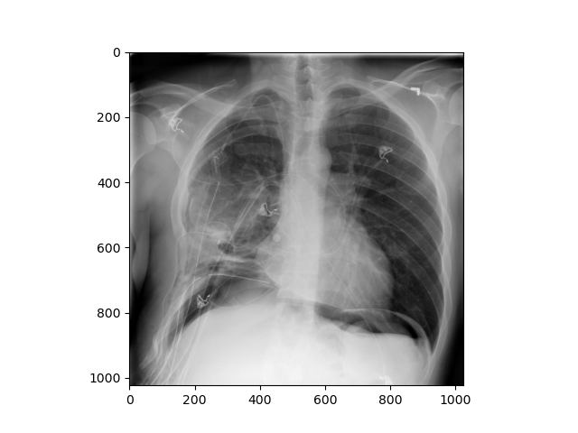

```python
plt.imshow(dcm.pixel_array, cmap='gray')
```

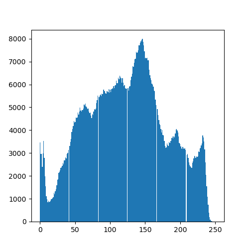

```python
plt.figure(figsize=(5,5))
plt.hist(dcm.pixel_array.ravel(), bins=256) # ravel return contiguous flattened array
```

```python
# calculate mean and standard deviaiton

mean_intensity, std_intensity = np.mean(dcm.pixel_array), np.std(dcm.pixel_array)
print('mean :', mean_intensity, ', std :',std_intensity)
```

```
mean : 123.25588417053223 , std : 57.47256019573095
```

```python
# Normalise the image

new_img = dcm.pixel_array.copy()
new_img = (new_img - mean_intensity)/std_intensity
```

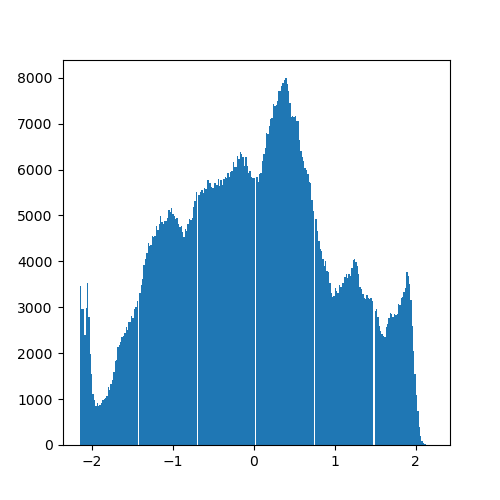

```python
# Plotting the normalized pixel intensity

plt.figure(figsize=(5,5))
plt.hist(new_img.ravel(), bins=256)
```

```python
bbox
```

|  | Unnamed: 0 | Image Index | Finding Label | Bbox [x | y | w | h] |
| --- | --- | --- | --- | --- | --- | --- | --- |
| 0 | 583 | dicom_00023075_033.dcm | Mass | 239.502222 | 535.077934 | 72.817778 | 65.991111 |
| 1 | 584 | dicom_00029579_005.dcm | Mass | 609.280000 | 189.193490 | 73.955556 | 71.680000 |
| 2 | 585 | dicom_00013659_019.dcm | Mass | 559.217778 | 167.575712 | 102.400000 | 136.533333 |

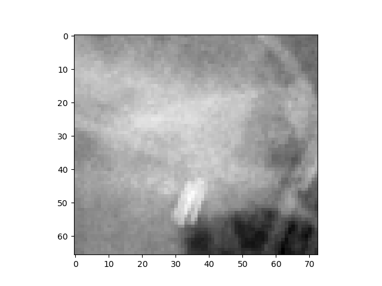

```python
# Visualising the suspecious mass

plt.imshow(dcm.pixel_array[535:(535+66),240:(240+73)], cmap='gray')
```

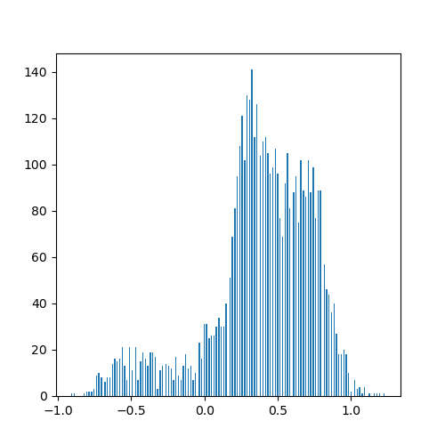

```python
# Plotting histogram of normalised pixel intensities for mass

plt.figure(figsize=(5,5))
plt.hist(new_img[535:(535+66),240:(240+73)].ravel(), bins=256)
```

### Image 2

```python
bbox
```

|  | Unnamed: 0 | Image Index | Finding Label | Bbox [x | y | w | h] |
| --- | --- | --- | --- | --- | --- | --- | --- |
| 0 | 583 | dicom_00023075_033.dcm | Mass | 239.502222 | 535.077934 | 72.817778 | 65.991111 |
| 1 | 584 | dicom_00029579_005.dcm | Mass | 609.280000 | 189.193490 | 73.955556 | 71.680000 |
| 2 | 585 | dicom_00013659_019.dcm | Mass | 559.217778 | 167.575712 | 102.400000 | 136.533333 |

```python
dcm2 = pydicom.dcmread('dicom_00029579_005.dcm')
```

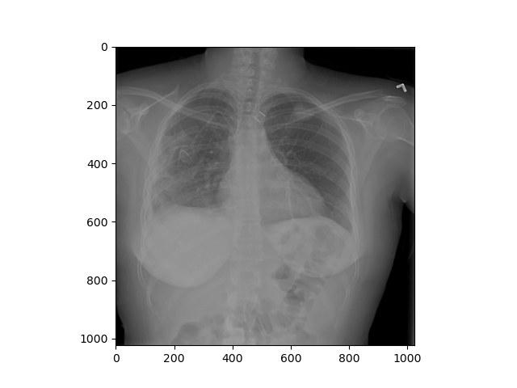

```python
plt.imshow(dcm2.pixel_array, cmap='gray')
```

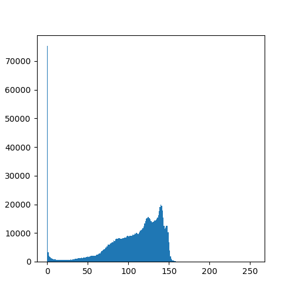

```python
plt.figure(figsize=(5,5))
plt.hist(dcm2.pixel_array.ravel(), bins=256)
```

```python
mean2_intensity, std2_intensity = np.mean(dcm.pixel_array), np.std(dcm.pixel_array)
print('mean :',mean2_intensity,', std :',std2_intensity)
```

```
mean : 123.25588417053223 , std : 57.47256019573095
```

```python
new_img2 = dcm2.pixel_array.copy()
new_img2 = (new_img - mean2_intensity)/std2_intensity
```

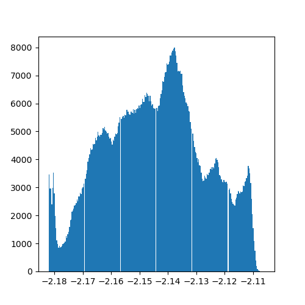

```python
plt.figure(figsize=(5,5))
plt.hist(new_img2.ravel(), bins=256)
```

```python
bbox
```

|  | Unnamed: 0 | Image Index | Finding Label | Bbox [x | y | w | h] |
| --- | --- | --- | --- | --- | --- | --- | --- |
| 0 | 583 | dicom_00023075_033.dcm | Mass | 239.502222 | 535.077934 | 72.817778 | 65.991111 |
| 1 | 584 | dicom_00029579_005.dcm | Mass | 609.280000 | 189.193490 | 73.955556 | 71.680000 |
| 2 | 585 | dicom_00013659_019.dcm | Mass | 559.217778 | 167.575712 | 102.400000 | 136.533333 |

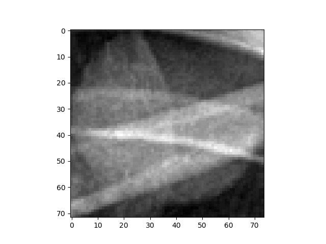

```python
plt.imshow(dcm2.pixel_array[189:(189+72),609:(609+74)], cmap='gray')
```

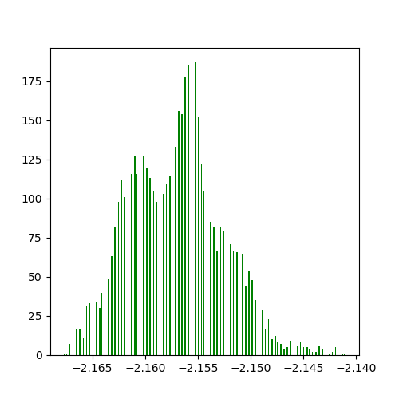

```python
plt.figure(figsize=(5,5))
plt.hist(new_img2[189:(189+72),609:(609+74)].ravel(), bins=256, color='green')
```

### Image 3

```python
bbox
```

|  | Unnamed: 0 | Image Index | Finding Label | Bbox [x | y | w | h] |
| --- | --- | --- | --- | --- | --- | --- | --- |
| 0 | 583 | dicom_00023075_033.dcm | Mass | 239.502222 | 535.077934 | 72.817778 | 65.991111 |
| 1 | 584 | dicom_00029579_005.dcm | Mass | 609.280000 | 189.193490 | 73.955556 | 71.680000 |
| 2 | 585 | dicom_00013659_019.dcm | Mass | 559.217778 | 167.575712 | 102.400000 | 136.533333 |

```python
dcm3 = pydicom.dcmread('dicom_00013659_019.dcm')
```

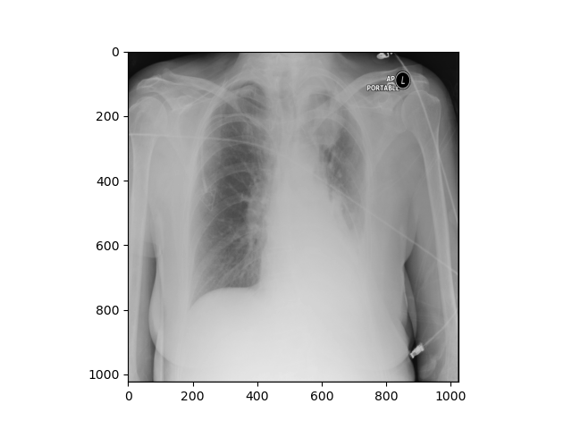

```python
plt.imshow(dcm3.pixel_array, cmap='gray')
```

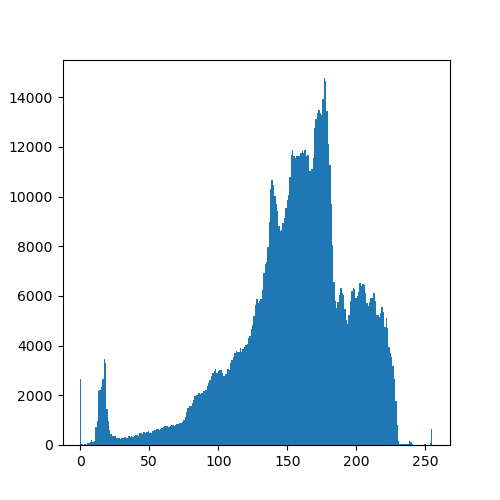

```python
plt.figure(figsize=(5,5))
plt.hist(dcm3.pixel_array.ravel(), bins=256)
```

```python
mean3_intensity, std3_intensity = np.mean(dcm3.pixel_array), np.std(dcm3.pixel_array)
print('mean :',mean3_intensity,', std :', std3_intensity)
```

```
mean : 155.60211944580078 , std : 43.776203799182035
```

```python
img3 = dcm3.pixel_array.copy()
img3 = (img3 - mean3_intensity)/std3_intensity
```

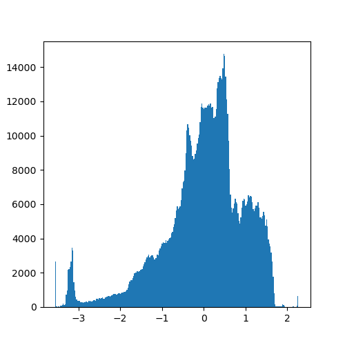

```python
plt.figure(figsize=(5,5))
plt.hist(img3.ravel(), bins=256)
```

```python
bbox
```

|  | Unnamed: 0 | Image Index | Finding Label | Bbox [x | y | w | h] |
| --- | --- | --- | --- | --- | --- | --- | --- |
| 0 | 583 | dicom_00023075_033.dcm | Mass | 239.502222 | 535.077934 | 72.817778 | 65.991111 |
| 1 | 584 | dicom_00029579_005.dcm | Mass | 609.280000 | 189.193490 | 73.955556 | 71.680000 |
| 2 | 585 | dicom_00013659_019.dcm | Mass | 559.217778 | 167.575712 | 102.400000 | 136.533333 |

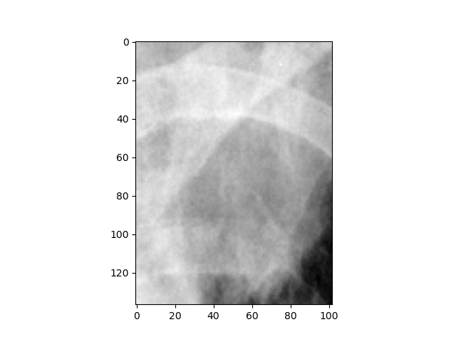

```python
plt.imshow(dcm3.pixel_array[168:(168+137),559:(559+102)], cmap='gray')
```

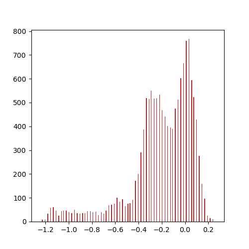

```python
plt.figure(figsize=(5,5))
plt.hist(img3[168:(168+137),559:(559+102)].ravel(), bins=256, color='brown')
```